# Data mining, concepts and techniques

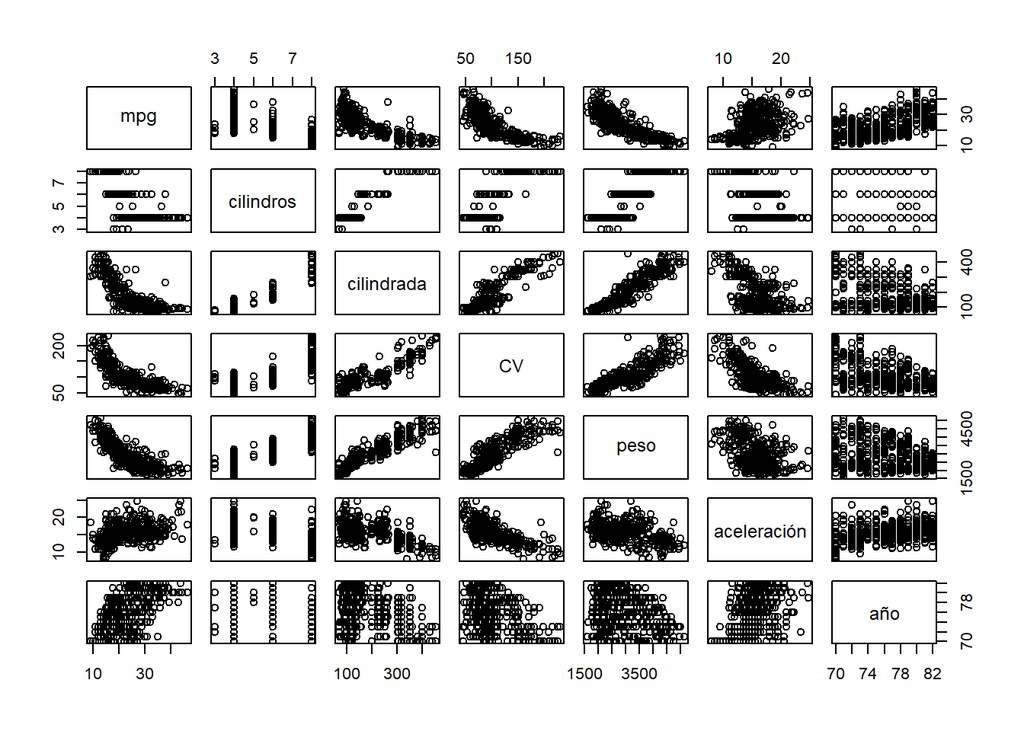

```r
# We get a plot matrix for each variable relationship between pairs.
plot(coches[1:7])    #in this analysys i am not interested in the name of the car or its origin
```

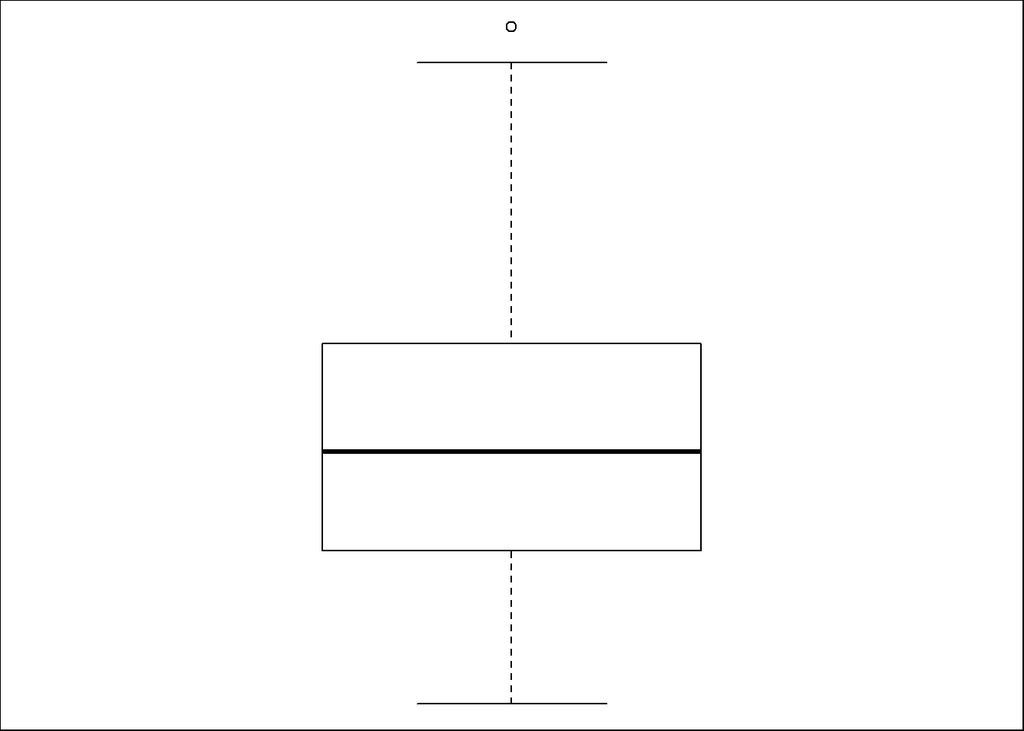

```r
boxplot(coches$mpg)    #we find an outlier point here
```

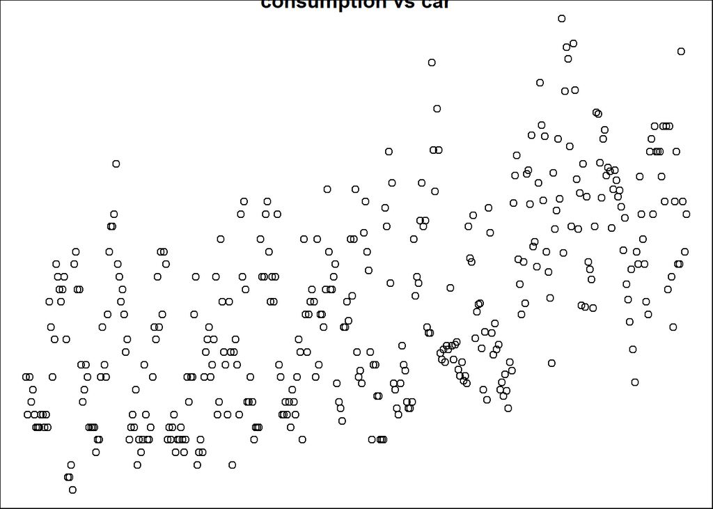

```r
#here we see the MPG for each car
plot(coches$mpg, main="consumption vs car", sub="each obs. in X asociated to a consumption in Y",
  xlab="observation num.", ylab="MPG" )
```

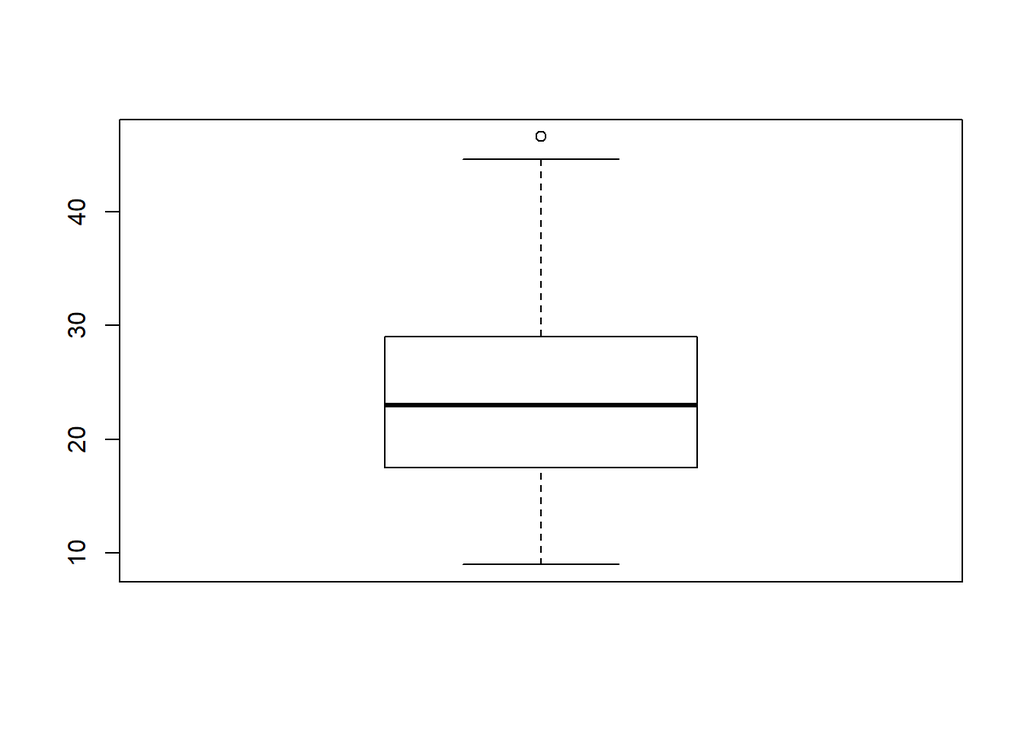

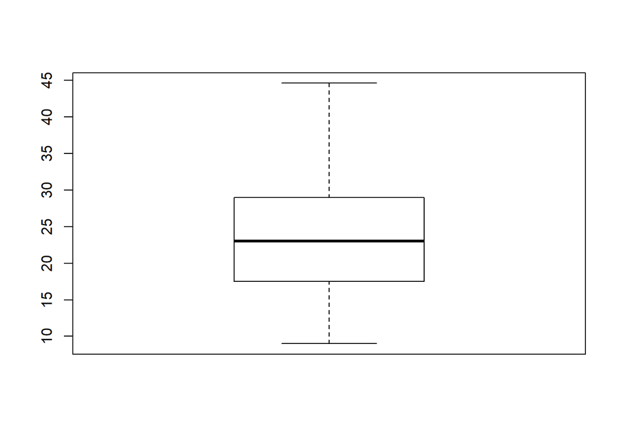

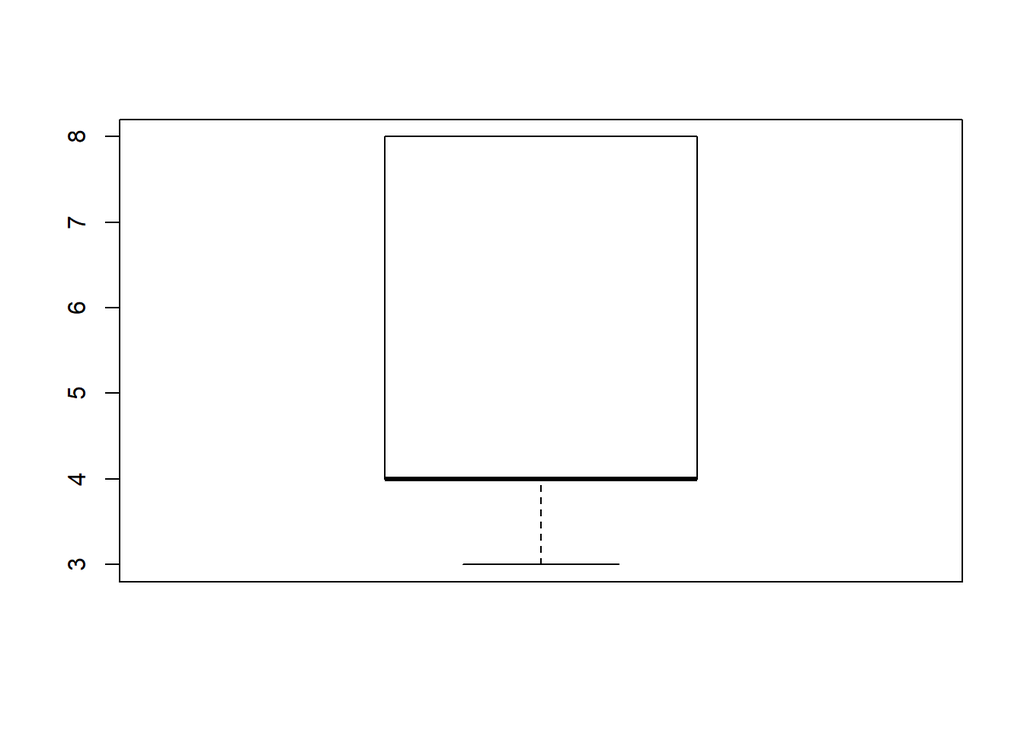

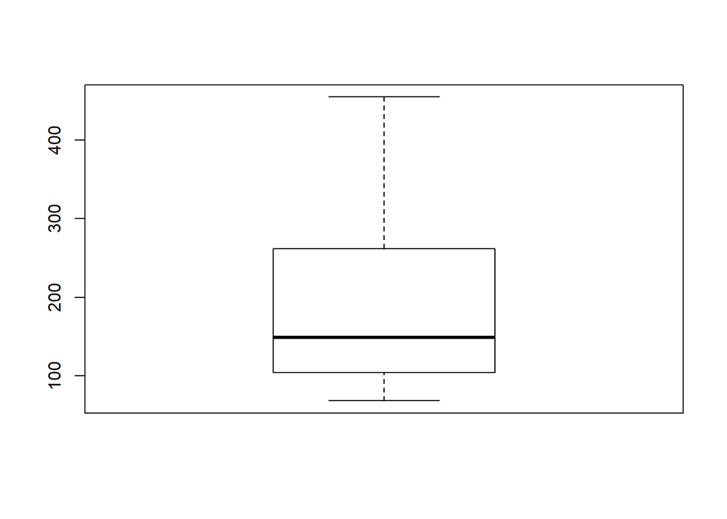

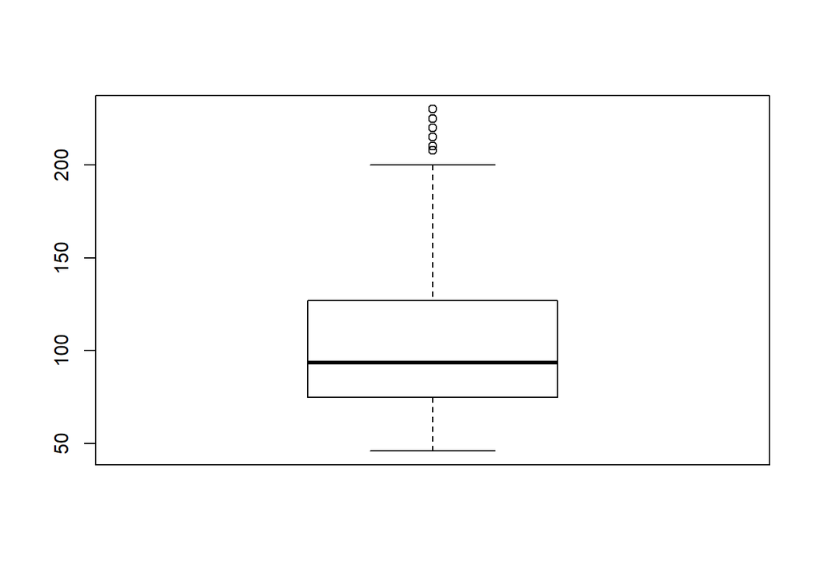

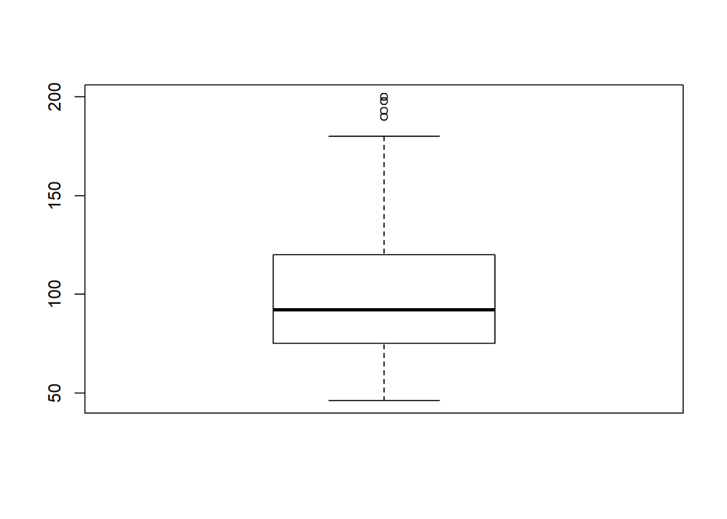

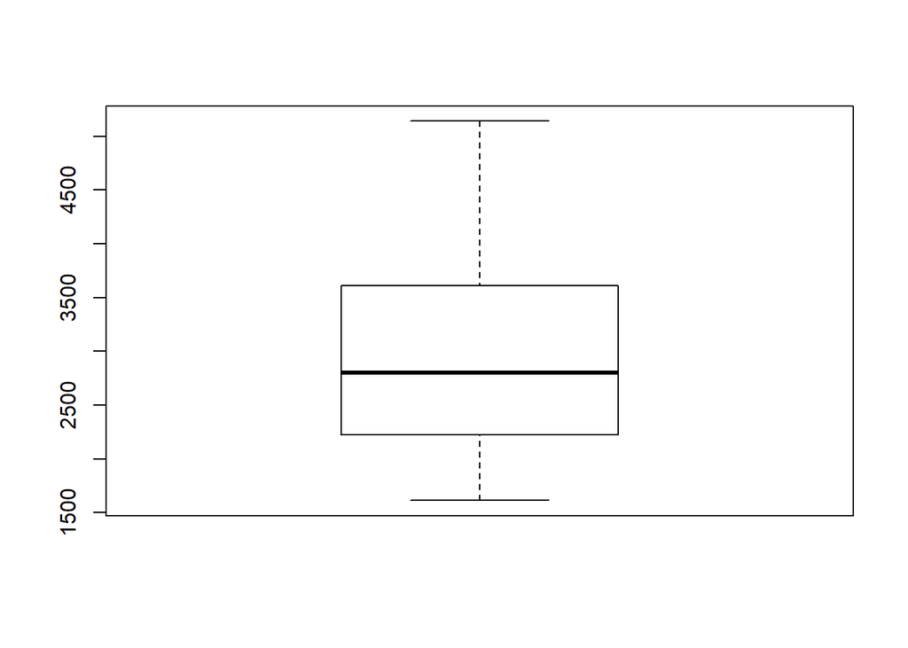

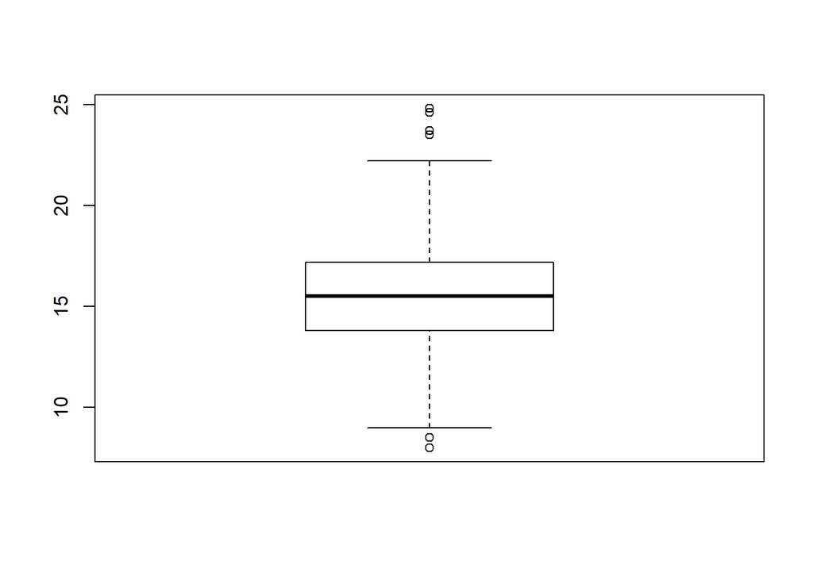

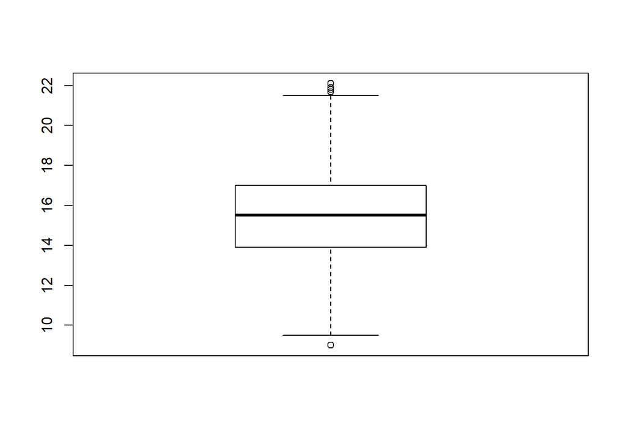

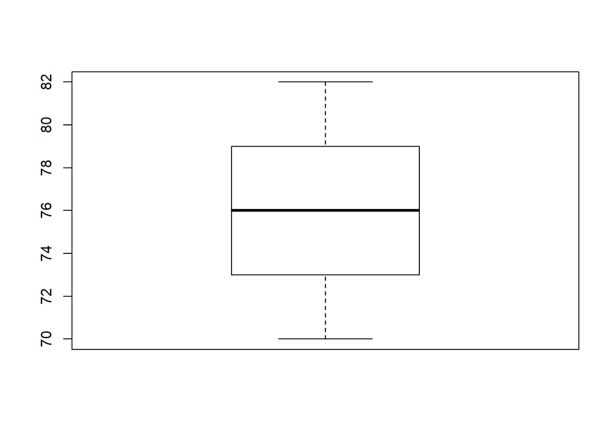

```r
#Not checking the last 2 variables since we cannot consider them outliers

#importing data table and outliers
library(data.table)
library(outliers)



remove_outliers <- function(x, na.rm = TRUE, ...) {
  qnt <- quantile(x, probs=c(.25, .75), na.rm = na.rm, ...)
  H <- 1.5 * IQR(x, na.rm = na.rm)
  y <- x
  y[x < (qnt[1] - H)] <- NA
  y[x > (qnt[2] + H)] <- NA
  y
}

######################### ######################### #########################
for (i in 1:7) {
  x<-coches[[i]]
y <- remove_outliers(x)

boxplot(x)
boxplot(y)
    }
```

```r
  #if ( length(outliers_index) != 0) {
 # coches_outR<- coches[-outliers_index,]
#  }

######################### ######################### #########################
# I am showing pre and post function in boxplot pais, reflection the Outlier elimination. Note: in some cases there is no visible change sice there were no Outliers, I plot it even so to deal with the automatization premise from columns 1:7)


# There is a scale change. I has no importance that in some cases there are still outliers. In the second case for instance, the shown outliers are there after the first removal (the most extreme values are out of our set now, but if we iterate further, we will continue eliminating elements that are necessary for the analysys.)

#Key point: check outliers, but do not modificate the dataset until it fits in what it is expected.
```

```r
#we can deal with outliers in 3 ways:

# 1. imputation: reemplace it with another value (mode, median...). I won't do it in the case of value 46 mpg

# 2. capping: for values out of 1st and 3rd quartiles, we can reemplace them for the values of percentil 5% and 95% (upper or lower depending on where they are)

# 3. prediction: if I have NA values in a intermediate point, and I am able to create a predictive model for this variable, i can reemplaze the NA values with the generated predictions [this method would be useful for NA's in CV variable]
```

# Confidence interval (CI)

Calculate CI at 97% for mpg

Do it manually, do not use R functions that give direct results (t.test or similars). It is allowed to use qnorm, pnorm, qt and pt

```r
# sample mean calculation
(mediaMPG <- mean(coches$mpg))
```

```
## [1] 23.51457
```

```r
mediaMPG
```

```
## [1] 23.51457
```

```r
#sample standard deviation
(sdMPG <- sd(coches$mpg))
```

```
## [1] 7.815984
```

```r
sdMPG
```

```
## [1] 7.815984
```

```r
#size of the sample
(n <- dim(coches)[1])
```

```
## [1] 398
```

```r
n
```

```
## [1] 398
```

```r
#confidence level 97%:

alpha <- 1 - 0.97

# standard error
errorTipico <- sdMPG / sqrt(n)

#value of statistic Z :

z <- qnorm(1 - alpha/2)
z
```

```
## [1] 2.17009
```

```r
# error margin
error <- z * errorTipico
error
```

```
## [1] 0.8501978
```

```r
# limits are mean+/- ((qnorm(1-alpha/2))*((sd(mpg)/sqrt(n))))  I got them already simplified as standard error, Z, and error margin, thus I only got to add or substract the error to the mean, depending on the case


#inferior limit

limite_inferior<- mediaMPG-error
limite_inferior
```

```
## [1] 22.66438
```

```r
#superior limit

limite_superior<- mediaMPG+error
limite_superior
```

```
## [1] 24.36477
```

# Hypothesis testing

Someone says that the expected value for MPG is, as minimal, 25 units. Based on data, can we reject this afirmation with a confidence level of 95%?

Note: Do it manually, do not use R functions that give direct results (t.test or similars). It is allowed to use qnorm, pnorm, qt and pt. A) Write the test to perform. B) Calculate the test statistic, critical value and p-value C) Interpretation of results.

1. Write the test to perform. I will use t Student statistic, since the population variance is unknown

H_o : mu_mpg >= 25 population mean for mpg is higher or equal to 25, null hypothesis

H_1 : mu_mpg < 25 population mean for de mpg is lesser than 25, alternative hypothesis

2. Calculate the test statistic, critical value and p-value

Some of the variables are already solved from the previous step, I will reuse them (n, errorTipico).

```r
# Acceptance region for null hypothesis
alpha <- 0.05
valorCritico <- qt(alpha, df = n-1)
valorCritico
```

```
## [1] -1.648701
```

```r
#calculated value for statistic
estadistico <- (mediaMPG -25 ) / (errorTipico)
estadistico
```

```
## [1] -3.791484
```

```r
p <- pt(estadistico, df = n-1, lower.tail = TRUE)
p
```

```
## [1] 8.651167e-05
```

```r
# p is not higher than 0.05. I discard the null hypothesis in this case
```

3. The statistic value (-3.791484) is out of the acceptance region (critical value of -1.648), therefore we discard the null hypothesis and we accept the alternative hypothesis.

We can assure with 95% confidence level, that population mean for MPG is lesser than 25

# Correlation

1. Get the correlations between numerical variables. Note: check missings since they will be problematic.
2. Show the correlations with a graph. You can use “corrplot” for instance.
3. Interpretation of results from the previous step.
1. Get the correlations between numerical variables. Note: check missings since they will be problematic.

```r
# in this case it would be suitable to perform an estimation of every NA. Since it is not asked in this point and we have enough datapoints, we will remove 6 from the 398 observations, with the option of "use only complete observations". I leave out of analysis the name of the car, as it has no influence with the other variables and makes the analysis less clear.


matriz_cor<-cor(coches[1:8],use="complete.obs")
matriz_cor
```

```
##                    mpg  cilindros cilindrada         CV       peso
## mpg          1.0000000 -0.7776175 -0.8051269 -0.7784268 -0.8322442
## cilindros   -0.7776175  1.0000000  0.9508233  0.8429834  0.8975273
## cilindrada  -0.8051269  0.9508233  1.0000000  0.8972570  0.9329944
## CV          -0.7784268  0.8429834  0.8972570  1.0000000  0.8645377
## peso        -0.8322442  0.8975273  0.9329944  0.8645377  1.0000000
## aceleración  0.4233285 -0.5046834 -0.5438005 -0.6891955 -0.4168392
## año          0.5805410 -0.3456474 -0.3698552 -0.4163615 -0.3091199
## origen       0.5652088 -0.5689316 -0.6145351 -0.4551715 -0.5850054
##             aceleración        año     origen
## mpg           0.4233285  0.5805410  0.5652088
## cilindros    -0.5046834 -0.3456474 -0.5689316
## cilindrada   -0.5438005 -0.3698552 -0.6145351
## CV           -0.6891955 -0.4163615 -0.4551715
## peso         -0.4168392 -0.3091199 -0.5850054
## aceleración   1.0000000  0.2903161  0.2127458
## año           0.2903161  1.0000000  0.1815277
## origen        0.2127458  0.1815277  1.0000000
```

2. Show the correlations with a graph. You can use “corrplot” for instance.

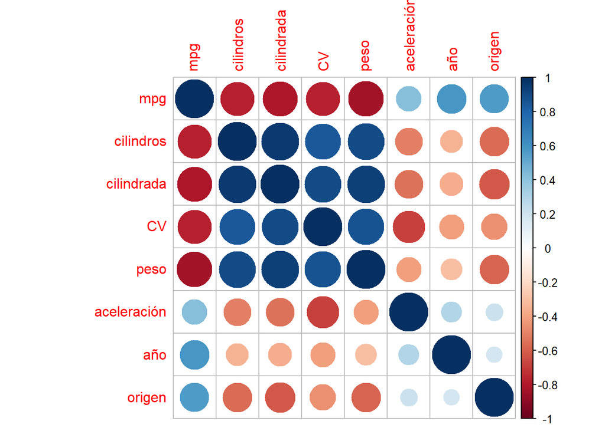

```r
library(corrplot)

corrplot(matriz_cor)
```

C) Interpretad el resultado del apartado anterior.

In the main diagonal, same variables meet, so it is always 1. Check only half matrix, since it is a simmetrical matrix and the other half is duplicated information.

In red, we observe the negative influence relationships (when one grows, the other decreases). As expected, when “cilinders”, “cilinder volume”, “CV” or “weight” grows, “MPG” decreases (this is, there is a higher fuel consumption)

Cilinders, cilinder volume and weight are always growing positively with each other in a similar manner. That could indicate, that if we make a variance contribution analysis later, maybe these 4 variables can be summed up in only one due to the big interdependency that they show.

The variable “year” for instance, has a big positive dependency with mpg, the means the more modern the car is, higher mpg and therefore lesser fuel consumption

The variable “origin” grows with mpg, and is lesser with cilinders and cilinder volume. Even when it is not asked, I could have been better to change origin to 3 character values (Europe, Asia, America), since for explanation purposes it makes no sense showing it numerically.